# STAT2006 FINAL ASSESMENT

#### Notes:

- Project tracked with git
- Datasets found under `./data/`

#### Librarys

```r
library(tidyverse)
library(tidymodels)
library(leaps)
```

### Question 1.

#### Section 1a.

Read the dataset project_data1.csv into R and perform an 80/20 training–test split using a random seed of 2006. Clearly show the training and test datasets created. (5 marks)

```r
# read the dataset ./data/project_data1.csv
project_data1 <- read_csv("./data/project_data1.csv")
# preform an 80/20 split with seed of 2006
set.seed(2006)

split_data1 <- initial_split(project_data1, prop = 0.8)
train_data1 <- training(split_data1)
test_data1 <- testing(split_data1)

# clearly show the training and test datasets
print(train_data1)
```

```
## # A tibble: 40 × 26
##         y     X1     X2      X3     X4      X5      X6       X7     X8     X9
##     <dbl>  <dbl>  <dbl>   <dbl>  <dbl>   <dbl>   <dbl>    <dbl>  <dbl>  <dbl>
##  1 18.7   -0.923  0.865  0.576  -2.21   0.392   0.0912 -0.00902  1.90   1.47
##  2 -6.01  -1.18   0.441 -0.0464  0.277 -0.344   0.418   0.215    1.06  -2.05
##  3 23.2   -0.641 -0.224  1.88   -1.40  -0.858  -0.203  -1.37     0.522  0.698
##  4 20.4    1.18   0.715  0.482  -0.414 -0.846   0.661  -1.06     0.404 -0.435
##  5 -8.23   1.59  -0.398  0.0875  0.509  0.443   1.10   -1.40    -0.568 -1.41
##  6  2.74  -0.424 -1.00   0.975  -0.586  0.669  -0.625   0.188   -1.45  -0.808
##  7 14.0    1.25   0.624 -0.0719 -0.583  0.0368 -0.163   0.646    1.51  -0.947
##  8 -2.76   0.562 -0.189 -0.991  -1.03   0.405   0.384   0.982    0.240 -1.25
##  9  0.240 -1.47  -0.569  0.702  -0.434 -0.171  -0.289  -0.131   -0.699 -0.305
## 10 -5.87  -0.806  1.27  -1.42   -0.168 -0.647   0.579  -0.355   -2.32   0.324
## # ℹ 30 more rows
## # ℹ 16 more variables: X10 <dbl>, X11 <dbl>, X12 <dbl>, X13 <dbl>, X14 <dbl>,
## #   X15 <dbl>, X16 <dbl>, X17 <dbl>, X18 <dbl>, X19 <dbl>, X20 <dbl>,
## #   X21 <dbl>, X22 <dbl>, X23 <dbl>, X24 <dbl>, X25 <dbl>
```

```r
print(test_data1)
```

```
## # A tibble: 10 × 26
##         y      X1     X2       X3      X4      X5     X6      X7     X8      X9
##     <dbl>   <dbl>  <dbl>    <dbl>   <dbl>   <dbl>  <dbl>   <dbl>  <dbl>   <dbl>
##  1  13.9   1.48   -0.700  1.89    -0.443   1.25   -0.621  0.821   0.758  1.74
##  2  -1.44  0.467  -2.13   1.26    -1.24    2.36   -0.908  0.137   1.10  -1.07
##  3  -5.95 -0.614  -1.15   0.801    1.58   -0.592  -0.612 -0.236   0.265 -0.274
##  4  19.2  -0.622   0.752  0.925    0.0494 -0.357  -1.78  -0.347   0.795 -0.470
##  5  16.0   2.39   -1.66  -0.00488 -0.458  -2.24    0.676  0.0189 -1.93  -0.0911
##  6   6.88  0.210   1.32   0.00877 -1.11    0.628   2.03   0.349  -0.761  1.78
##  7  -4.47  0.205   0.251 -1.14     0.381   0.0680 -0.833 -0.369   0.386 -0.695
##  8   6.58  0.174   0.782  0.396    1.03   -0.806   0.211 -1.60    1.22   1.26
##  9 -27.3   0.220   0.630 -0.599    1.15    2.21    1.11   0.236  -0.770 -0.186
## 10  17.2   0.0621 -0.153  2.41    -0.625   1.27   -0.661  0.257   1.66  -0.461
## # ℹ 16 more variables: X10 <dbl>, X11 <dbl>, X12 <dbl>, X13 <dbl>, X14 <dbl>,
## #   X15 <dbl>, X16 <dbl>, X17 <dbl>, X18 <dbl>, X19 <dbl>, X20 <dbl>,
## #   X21 <dbl>, X22 <dbl>, X23 <dbl>, X24 <dbl>, X25 <dbl>
```

Using the training dataset, perform forward stepwise variable selection with the regsubsets() function. Use all available predictors and set the maximum number of variables to 25. (5 marks)

```r
forward_stepwise <- regsubsets(
  y ~ .,                          # Y is predicted by the 25 X columns
  data = train_data1,             # uses the training dataset
  nvmax = 25,                     # set the maximum number of variables to 25
  method = "forward"              # forward stepwise variable selection
)

forward_summary <- summary(forward_stepwise)
```

Obtain the Cp values from the fitted forward stepwise model and produce a plot of Cp versus the number of predictors 𝑝. Clearly highlight the model corresponding to the minimum Cp value on the plot. (4 marks)

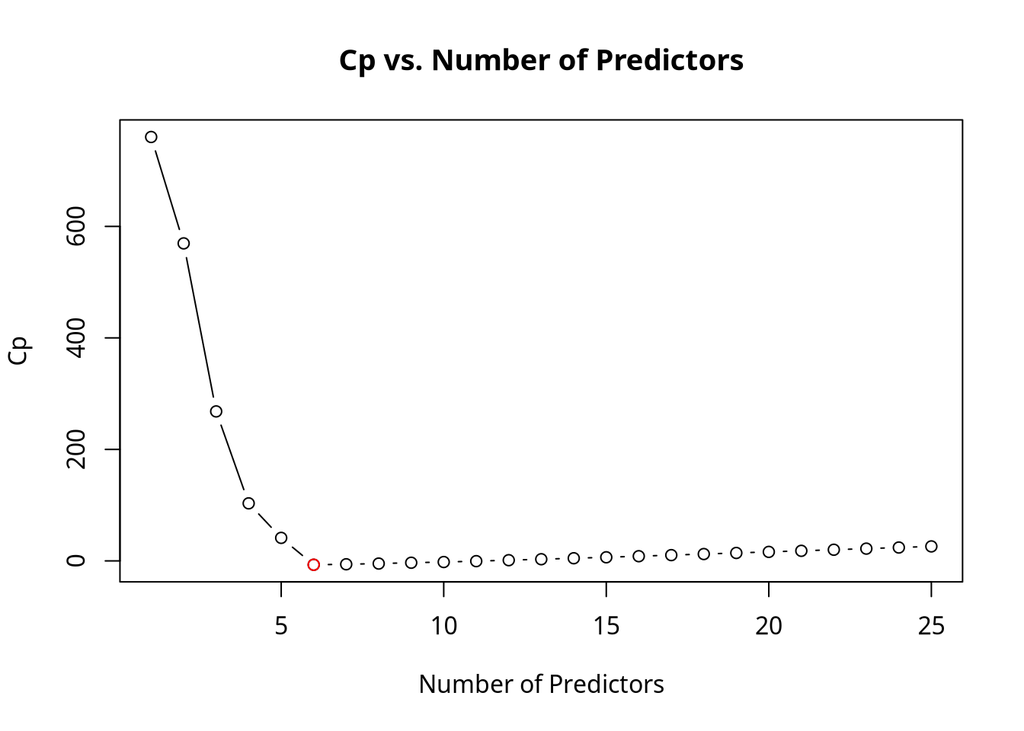

```r
cp_vals <- forward_summary$cp
predictors <- 1:length(cp_vals)

plot(
  predictors,                            # X data
  cp_vals,                               # Y data
  type = "b",                            # shows both points and lines
  xlab = "Number of Predictors",         # X label
  ylab = "Cp",                           # Y label
  main = "Cp vs. Number of Predictors"   # Title
)

min_cp <- which.min(cp_vals) # Finds lowest Cp value

# changes the point to red
points(
  predictors[min_cp],
  cp_vals[min_cp],
  col = "red",
)
```

#### Section 1b.

Using the training dataset obtained in Q1(a), perform the following analyses using 5-fold cross-validation with a random seed of 2006.

Fit the following penalized regression models using cv.glmnet():

- Lasso regression (𝛼 = 1)
- Ridge regression (𝛼 = 0)
- Elastic-net regression (𝛼 = .5)

Use the same fold allocation (hint: see foldid argument) for all three models and produce the corresponding cross-validation plots. (6 marks)

Extract the lambda.1se value for each of the three fitted models and fit the final lasso, ridge, and elastic-net models using the extracted tuning parameters. (6 marks)

Fit a linear regression model using the predictors selected from the forward stepwise selection procedure. (2 marks)

Use the test dataset to obtain predictions for all four fitted models: – Lasso – Ridge – Elastic-net – Linear regression model selected using forward selection Compute and present the RMSE values for all four models in a suitable table ordered from the smallest RMSE to the largest RMSE. (5 marks)

Based on the RMSE values, identify the best-performing model. (2 marks)

### Question 2.

Read the dataset project_data2.csv into R and perform a 75/25 training–test split using a random seed of 2006. (5 marks)

Using the training dataset, fit elastic-net regression models using cv.glmnet() for the following values of 𝛼: 𝛼 = 0.0, .1 , .2, …, 1.0

Store the fitted cross-validation objects using a tibble list-column approach. (5 marks)

Extract the lambda.1se value corresponding to each value of 𝛼𝛼 and fit the associated elastic-net model using glmnet(). Store the fitted models in tibble list-columns. (7 marks)

Use the fitted models to predict the response values for the test dataset and compute the RMSE for each fitted model using a tibble list-column workflow. Present the RMSE values in ascending order and identify the optimal elastic-net model. (5 marks)

For the optimal elastic-net model, produce a scatter plot of predicted versus actual response values for the test dataset. Include the reference line 𝑦 = 𝑥 on the plot. (3 marks)

### Question 3.

The dataset heart-disease.csv is available in the Datasets folder. In this question, your objective is to build classification models for predicting the variable target.

The variables in the dataset are described below.

- age: age in years
- sex: sex (1 = male; 0 = female)
- cp: chest pain type
- trestbps: resting blood pressure (in mm Hg on admission to the hospital)
- chol: serum cholestoral in mg/dl
- fbs: fasting blood sugar > 120 mg/dl (1 = true; 0 = false)
- restecg: resting electrocardiographic results
- thalach: maximum heart rate achieved
- exang: exercise induced angina (1 = yes; 0 = no)
- oldpeak: ST depression induced by exercise relative to rest
- slope: the slope of the peak exercise ST segment
- ca: number of major vessels (0–3) coloured by fluoroscopy
- thal: 0 = normal; 1 = fixed defect; 2 = reversible defect
- target: 1 = presence of heart disease; 0 = absence of heart disease

For this question, you must use the tidyverse list-column approach with tibble, as demonstrated in the lectures and computer laboratories. In particular, you should use functions such as:

- map()
- map2()
- map_dbl()
- crossing()

from the purrr and tidyr packages to store fitted models, predictions, confusion matrices, and performance metrics.

Read the dataset heart-disease.csv into R and convert the variables target, sex, fbs, exang, ca, and thal into factors. Display an appropriate summary of the dataset. (3 marks)

Using a random seed of 2006, divide the data into an 80/20 training–test split using stratified sampling based on target. Verify that the proportions of target = 0 and target = 1 are similar in the original, training, and test datasets. (7 marks)

Perform 5-fold cross-validation on the training dataset using stratified folds based on target. Consider the following values of mtry for the random forest model mtry = 2,3,4,5,6,7,8,9,10,11,12

Use the crossing() function to create a tibble containing all combinations of cross-validation folds and mtry values. (5 marks)

For each combination of cross-validation fold and mtry value: – Create the corresponding training and validation datasets, – Fit a random forest classification model using the training fold, – Obtain predictions for the validation fold.

Store all fitted models and predictions using tibble list-columns. (5 marks)

For each fitted random forest model, compute the following performance measures based on the validation fold predictions: – Accuracy – Sensitivity – Specificity

Then compute the average value of each metric across the five cross-validation folds for every mtry value. Present the results in a suitable table ordered by decreasing accuracy. Identify the optimal mtry value. (10 marks)

Using the entire training dataset: – Fit a logistic regression model, – Fit a random forest model using the optimal mtry value selected from the cross-validation procedure.

Evaluate both models on the test dataset and report the following performance metrics: - Accuracy - Sensitivity - Specificity Also compute the AUC values and produce ROC curves for both models. Based on the overall results, comment on which model you would recommend for predicting heart disease. (10 marks)